# **Chi dorme bene**

### **Dataset iniziale**

Link al dataset: https://www.kaggle.com/datasets/hanaksoy/health-and-sleep-statistics  
Il dataset tratta un campione di 100 persone  
Le colonne presenti sono: Id, age, gender, sleep quality, bedtime, wake-up time, daily steps, calories burned, physical activity level, dietary habits, sleep disorders e medication usage  
Ho apportato delle modifiche al dataset, aggiungendo una colonna con le ore di sonno e un'altra che, in base all'età, indica la generazione di appartenenza

### **Le domande che mi sono posto**

- C'è una corrispondenza tra ore di sonno e qualità del sonno?
- Ci sono differenze nella qualità del sonno tra maschi e femmine?
- L'età è un fattore correlato alla qualità del sonno?
- Com'è la qualità del sonno in relazione alle abitudini?

### **Correlazione tra quantità e qualità del sonno**

C'è una correlazione positiva tra quantità di ore dormite e la qualità del sonno, confermato da un coefficiente di Pearson di 0.919

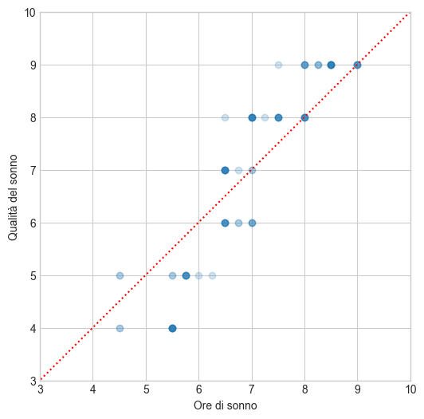

### **Qualità del sonno dei diversi sessi**

Possiamo vedere che in media le femmine dormono molto meglio rispetto ai maschi

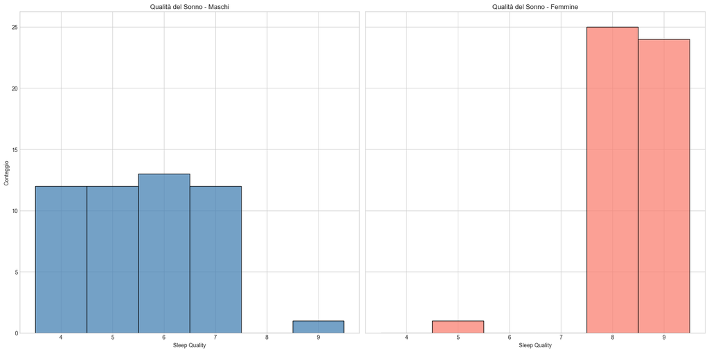

### **Quantità di sonno a confronto**

Però possiamo anche vedere che le femmine dormono di più in media

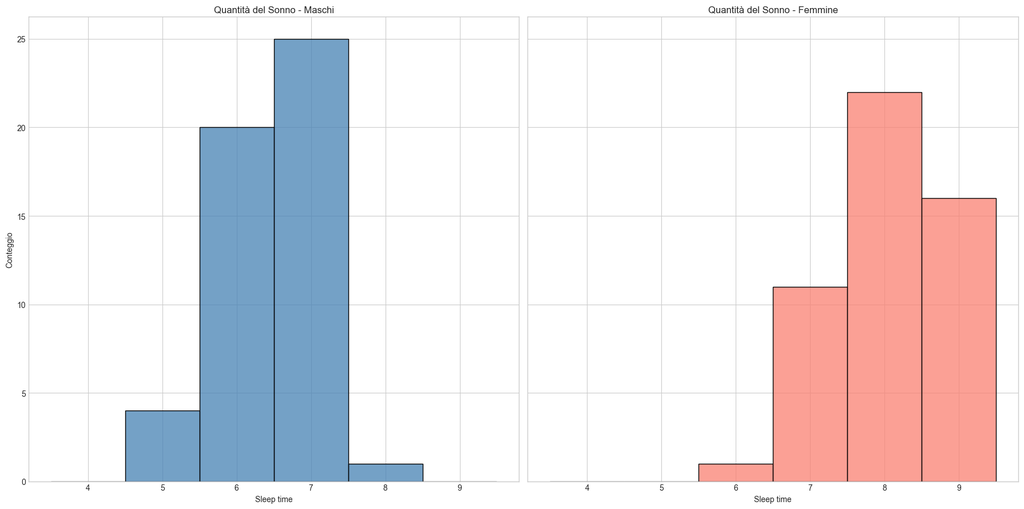

### **Correlazione sonno e genere**

Le femmine dormono di più in media, ma a parità di ore dormono meglio. I maschi hanno una qualità media del sonno di 5.58, le femmine di 8.42. Le femmine dormono in media 7.890 ore, i maschi 6.095

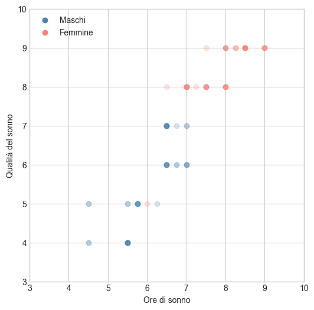

### **Il sonno delle varie generazioni**

Si può osservare come le varie generazioni dormono, partendo dalla Generazione X, passando per la Y e arrivando alla Z. Si nota che abbassando l'età aumenta la qualità del sonno, con una correlazione negativa di -0.848

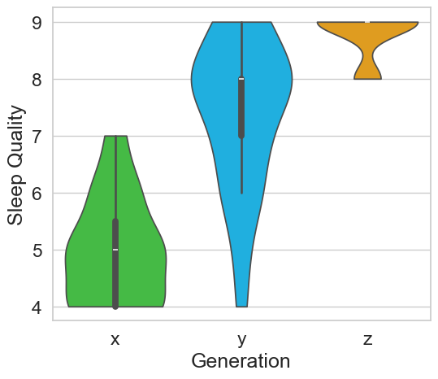

### **Distribuzione dei disturbi del sonno nelle varie generazioni**

Vediamo che al contrario della slide precedente, come ci aspetteremmo abbiamo un calo dei disturbi del sonno con il diminuire dell'età. La generazione X ha una percentuale del 74.1%, la generazione Y del 11.1%, e la generazione Z dello 0%

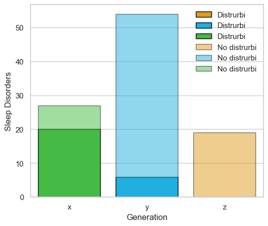

### **Abitudini e sonno**

Si nota una correlazione positiva tra sonno passi, con valore di 0.976. Inoltre si osserva che quelli che camminano molto tendono ad avere una buona alimentazione

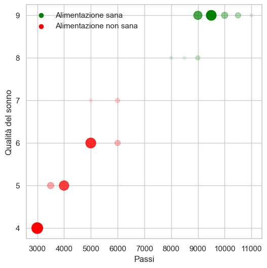

### **Utilizzo di medicinali sul sonno**

Chi utilizza medicinali ha una qualità del sonno peggiore rispetto a coloro che non li usano

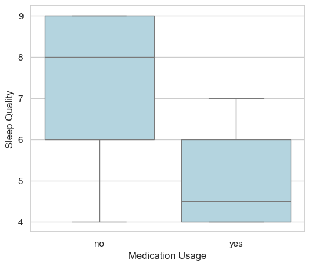

# **Conclusioni**

### **Punti di forza e debolezza di questa analisi**

**Punti di forza**

- Sono stati evidenziati vari fattori legati al sonno
- I fattori analizzati fanno parte delle abitudini e sono quindi modificabili

**Punti di debolezza**

- Il campione è piuttosto piccolo
- L'analisi sul sesso e sull'età non è completa, poiché le femmine sono in maggioranza giovani